# NDH802 - CLT

Huong

### Key takeaways

- Distribution of the random variable $X$ is **different from** the distribution of the sample mean $\bar{X}$.
- When number of observations is large, the the distribution of the sample mean $\bar{X}$ converges (approximates) to the normal distribution $N(\mu,\frac{\sigma^2}{n})$

### Illustration

Suppose we want to investigate the cheating behaviors among the Swedish students in a school year. We assume 2 outcomes, to cheat or not to cheat. Each student takes ten exams. The probability of cheating is 10% (similarly applicable for all exams, all students). To make it fancier, we write it in statistical language. Let $X$ denote the cheated exams, $X \sim Bin(10, 0.1)$

Let’s say we have big budget. We draw a sample of 100 students to investigate, and record the sample mean of the cheated exams. We call it $\bar{X_i}$. We repeat it 5000 times, i.e, we finally have 5000 values of $\bar{X_i}$. We put them together and call them $\bar{X}$. The distribution of $\bar{X}$ is plotted in the histogram below.

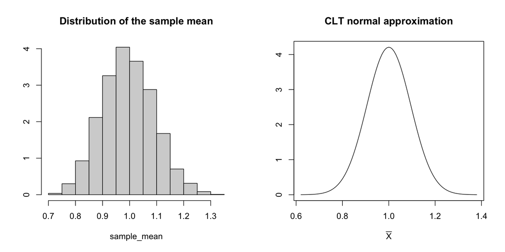

The great statisticians before us know that researchers usually work with tight budget. They suggest a theorem to approximate the distribution of sample mean to the normal distribution.**The Central Limit Theorem suggests that when we have a huge number of observations (the number of realities in our case), these means** follow a normal distribution. Formally, when $n$ is large, $\bar{X_n} \sim N(\mu,\frac{\sigma^2}{n})$.

```
## [1] 0.534
```

```
## [1] 0.5
```